# QSS3.9.1課題

[佐藤 慧](https://keisato0.github.io/)

2020年7月3日

```r
library(tidyverse)
library(magrittr)
library(patchwork)

gayreshaped <- read_csv("gayreshaped.csv")
ccap2012 <- read_csv("ccap2012.csv")
```

`gayreshaped`と`ccap2012`の構造は以下のようになっている．

```r
glimpse(gayreshaped)
```

```
## Rows: 11,948
## Columns: 6
## $ study     <dbl> 1, 1, 1, 1, 1, 1, 1, 1, 1, 1, 1, 1, 2, 2, 2, 2, 1, 2, 2, 2…
## $ treatment <chr> "No Contact", "No Contact", "No Contact", "No Contact", "R…
## $ therm1    <dbl> 91, 72, 69, 51, 50, 99, 3, 56, 63, 50, 50, 84, 2, 91, 52, …
## $ therm2    <dbl> 91, 72, 69, 51, 48, 99, 3, 56, 63, 54, 47, 84, 6, 90, 58, …
## $ therm3    <dbl> NA, NA, NA, NA, NA, NA, NA, NA, NA, NA, NA, NA, 0, 100, 53…
## $ therm4    <dbl> NA, NA, NA, NA, NA, NA, NA, NA, NA, NA, NA, NA, 6, 93, 59,…
```

```r
glimpse(ccap2012)
```

```
## Rows: 43,998
## Columns: 3
## $ X1       <dbl> 1, 2, 3, 4, 5, 6, 7, 8, 9, 10, 11, 12, 13, 14, 15, 16, 17, …
## $ caseid   <dbl> 328, 324, 100, 584, 63, 461, 81, 735, 565, 16, 705, 462, 99…
## $ gaytherm <dbl> 50, 95, 16, 50, 58, 100, 93, NA, 72, 71, 96, 50, 59, 26, 50…
```

# 第1波と第2波の相関

以下のように，研究1のコントロールグループだけ選ぶ．

```r
gayreshaped %>%
  filter(study == 1) -> study1

study1 %>%
  filter(treatment == "No Contact") %>%
  select(therm1, therm2) %>%
  cor(use = "complete.obs")
```

```
##           therm1    therm2
## therm1 1.0000000 0.9975817
## therm2 0.9975817 1.0000000
```

# 各波の相関

研究2のコントロールグループだけ選ぶ．

```r
gayreshaped %>%
  filter(study == 2) -> study2

study2 %>%
  filter(treatment == "No Contact") %>%
  select(-study,-treatment) -> study2_c

study2_c %>% cor(use = "pairwise.complete.obs")
```

```
##           therm1    therm2    therm3    therm4
## therm1 1.0000000 0.9734449 0.9594085 0.9709017
## therm2 0.9734449 1.0000000 0.9308287 0.9436621
## therm3 0.9594085 0.9308287 1.0000000 0.9343249
## therm4 0.9709017 0.9436621 0.9343249 1.0000000
```

各波間での相関は，最低でも0.930と極めて高く，こちらも操作が疑われる．

# 第1波とそれ以降の波の相関図

前項と同様研究2のコントロールグループを対象として，第1波とそれ以降の各波との関係をみる．

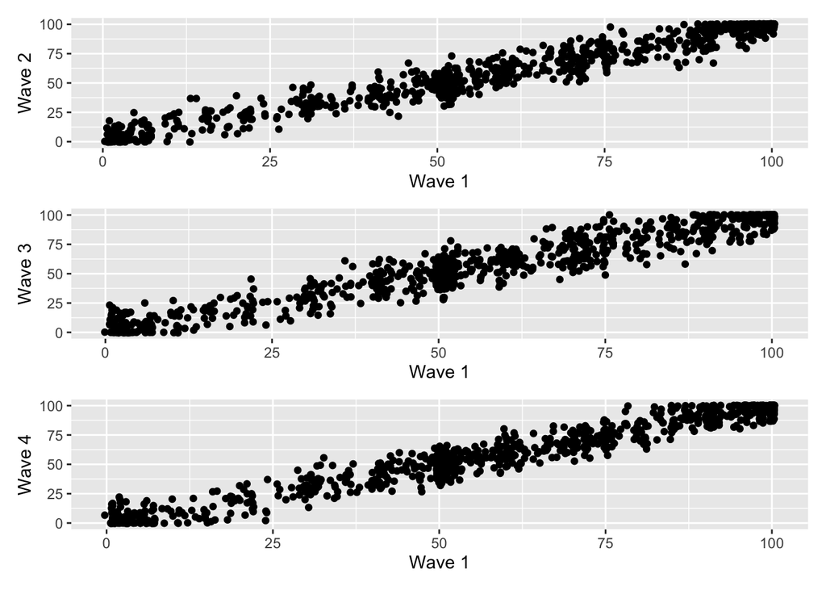

```r
study2_c %>%
  ggplot(mapping = aes(x = therm1, y = therm2)) +
  geom_jitter() +
  labs(x = "Wave 1", y = "Wave 2") -> plot2

study2_c %>%
  ggplot(mapping = aes(x = therm1, y = therm3)) +
  geom_jitter() +
  labs(x = "Wave 1", y = "Wave 3") -> plot3

study2_c %>%
  ggplot(mapping = aes(x = therm1, y = therm4)) +
  geom_jitter() +
  labs(x = "Wave 1", y = "Wave 4") -> plot4

plot2 / plot3 / plot4
```

目立った外れ値は全く見当たらず，上記と同様の疑いがもたれる．

# 感情温度分布の比較

感情温度の分布をccap，研究用データの研究1の第1波，研究2の第1波の三者間で比較する．

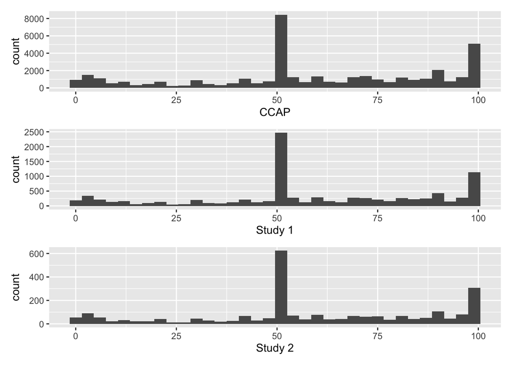

```r
ccap2012 %>%
  ggplot(mapping = aes(gaytherm)) +
  geom_histogram(binwidth = 3) +
  xlab("CCAP") -> plot_ccap

study1 %>%
  ggplot(mapping = aes(therm1)) +
  geom_histogram(binwidth = 3) +
  xlab("Study 1") -> plot_study1

study2 %>%
  ggplot(mapping = aes(therm1)) +
  geom_histogram(binwidth = 3) +
  xlab("Study 2") -> plot_study2

plot_ccap / plot_study1 / plot_study2
```

縦軸の目盛りが違うことに注意が必要だが，概形を比べるとCCAPと実際に使われたデータの感情温度の分布はほぼ同じである．したがって，データの流用が疑われる．

## 欠損値のパターンの確認

元のCCAPデータでは3097件，全体の約7%が欠損値である。

```r
ccap_na <- sum(is.na(ccap2012$gaytherm) == TRUE)
ccap_na
```

```
## [1] 3097
```

```r
ccap_na / nrow(ccap2012)
```

```
## [1] 0.07038956
```

ためしに研究1と研究2を10行ほど取り出し欠損値があらわれるパターンを確かめると，研究1では第3波以降は全行欠損値なのに対し，研究2では第2波以降ぽつぽつと欠損値があらわれるように見える。

```r
study1 %>%
  select(therm1:therm4) %>%
  sample_n(size = 10)
```

```
## # A tibble: 10 x 4
##    therm1 therm2 therm3 therm4
##     <dbl>  <dbl>  <dbl>  <dbl>
##  1     91     91     NA     NA
##  2    100     98     NA     NA
##  3     61     61     NA     NA
##  4     88     88     NA     NA
##  5    100    100     NA     NA
##  6     61     NA     NA     NA
##  7     50     NA     NA     NA
##  8    100    100     NA     NA
##  9     75     NA     NA     NA
## 10     71     71     NA     NA
```

```r
study2 %>%
  select(therm1:therm4) %>%
  sample_n(size = 10)
```

```
## # A tibble: 10 x 4
##    therm1 therm2 therm3 therm4
##     <dbl>  <dbl>  <dbl>  <dbl>
##  1     53     60     62     42
##  2     49     50     52     NA
##  3     22     26     36     NA
##  4     87     68     NA     88
##  5    100     NA     90     98
##  6     31     34     30     17
##  7     60     76     66     73
##  8     51     42     44     64
##  9     50     53     45     51
## 10     75     65     81     75
```

```r
colSums(is.na(study1)) %>%
  t() %>% data.frame() %>%
  select(therm1:therm4) %>%
  gather(key = "therm", value = "na") %>%
  mutate(cases = nrow(study1),
         na_ratio = na / cases)
```

```
##    therm   na cases  na_ratio
## 1 therm1    0  9507 0.0000000
## 2 therm2 1042  9507 0.1096035
## 3 therm3 9507  9507 1.0000000
## 4 therm4 9507  9507 1.0000000
```

```r
colSums(is.na(study2)) %>%
  t() %>% data.frame() %>%
  select(therm1:therm4) %>%
  gather(key = "therm", value = "na") %>%
  mutate(cases = nrow(study2),
         na_ratio = na / cases)
```

```
##    therm  na cases  na_ratio
## 1 therm1   0  2441 0.0000000
## 2 therm2 309  2441 0.1265875
## 3 therm3 328  2441 0.1343712
## 4 therm4 270  2441 0.1106104
```

# Q-Qプロット

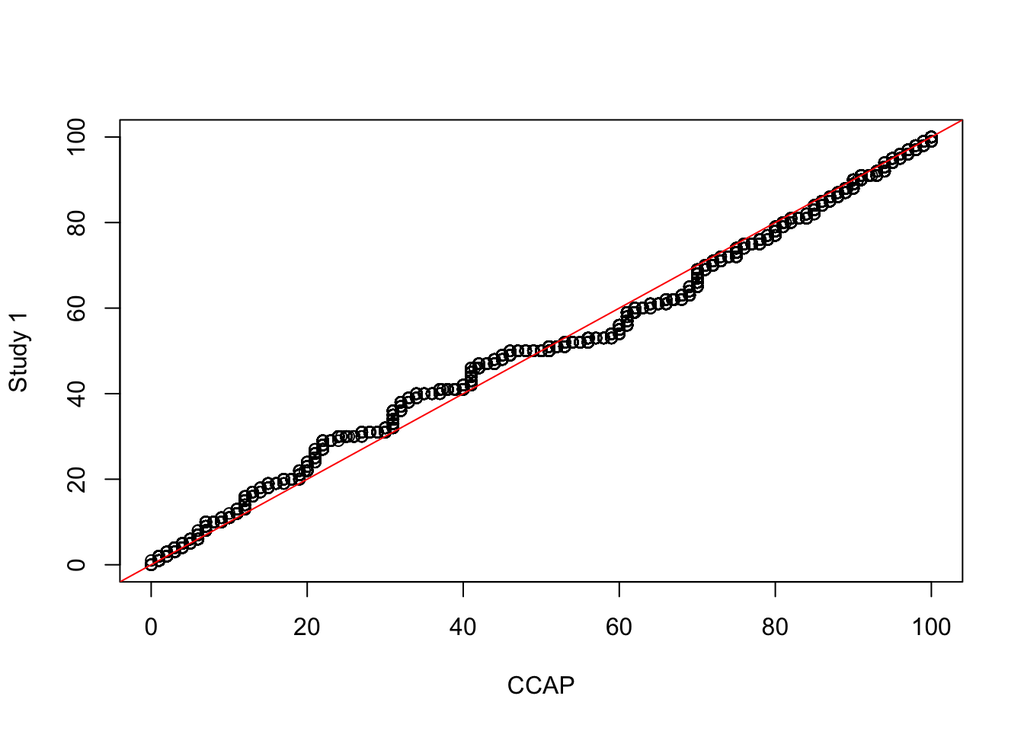

```r
qqplot(ccap2012$gaytherm, study1$therm1,
       xlab = "CCAP", ylab = "Study 1")
abline(0, 1, col = "red")
```

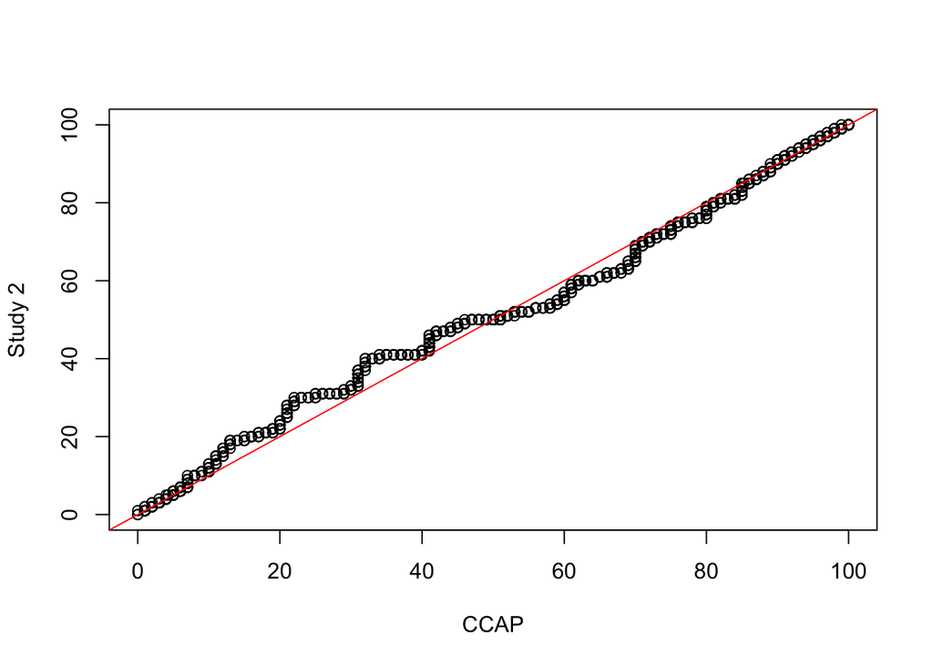

```r
qqplot(ccap2012$gaytherm, study2$therm1,
       xlab = "CCAP", ylab = "Study 2")
abline(0, 1, col = "red")
```

CCAPデータと比べると，研究1，2ともにおおよそ45度線付近で分布しており，分布の概形が変わらないことがわかる．上記と同様の疑いがもたれる．